# R Notebook

[output not shown]

# Informe escrito de resultados

## Figuras del articulo guia

Se pudo replicar con exito o parcial exito (figura 5) las graficas del articulo con la implementacion realizada en este proyecto, se pueden revisar todas las graficas mencionadas en el archivo **informe_icm.rmd** o revisar directamente los scripts que producen la informacion como lo son **figura_1**, **figura_2** y **figura_5_montecarlo_sim** en estos arcihvos de la carpeta **scripts** encontrara el codigo que se implemento para su generacion y en alguno de ellos la figura almacenada como un rds, en otros solo el data frame que contiene la informacion

## ICM con CBF vs ICM con transformacion logaritmica

[output not shown]

[output not shown]

A continuacion se presenta una tabla por cada funcion de apuesta donde se compara el retardo medio por cada Funcion de no conformidad para las probabilidades de falsa alarma de 5% y 10%

## Nota

A continuacion se presentan las tablas comaprativas asociadas a cada funcion de apuesta y cada medida de no conformidad para 5% y 10% de falsa alarma:

## Constant BF

Betting function: Constant BF

| Param.,\ Probab. of FA | 5% LR | 5% KNN | 5% MAD | 10% LR | 10% KNN | 10% MAD |
| --- | --- | --- | --- | --- | --- | --- |
| θ=100, μ1=1 | 21.82 | 182.54 | 120.71 | 17.62 | 131.47 | 91.81 |
| θ=100, μ1=1.5 | 12.98 | 39.91 | 23.80 | 10.92 | 27.65 | 20.16 |
| θ=100, μ1=2 | 10.92 | 16.19 | 13.40 | 9.49 | 13.50 | 11.63 |
| θ=200, μ1=1 | 25.69 | 147.58 | 111.77 | 21.95 | 132.46 | 89.60 |
| θ=200, μ1=1.5 | 15.21 | 40.14 | 26.75 | 12.67 | 32.83 | 22.59 |
| θ=200, μ1=2 | 13.09 | 18.63 | 15.83 | 11.42 | 15.71 | 13.59 |

## Mixtubre BF

Betting function: Mixture BF

| Param.,\ Probab. of FA | 5% LR | 5% KNN | 5% MAD | 10% LR | 10% KNN | 10% MAD |
| --- | --- | --- | --- | --- | --- | --- |
| θ=100, μ1=1 | 56.00 | 194.74 | 159.35 | 47.49 | 164.96 | 131.97 |
| θ=100, μ1=1.5 | 9.03 | 39.29 | 29.95 | 7.17 | 31.73 | 24.10 |
| θ=100, μ1=2 | 4.64 | 6.99 | 7.07 | 3.68 | 5.67 | 5.50 |
| θ=200, μ1=1 | 33.44 | 136.85 | 112.33 | 27.74 | 127.64 | 96.73 |
| θ=200, μ1=1.5 | 8.09 | 23.76 | 21.87 | 7.01 | 19.06 | 17.10 |
| θ=200, μ1=2 | 4.55 | 7.00 | 6.70 | 3.89 | 5.88 | 5.69 |

## Histogram BF

Betting function: Histogram BF

| Param.,\ Probab. of FA | 5% LR | 5% KNN | 5% MAD | 10% LR | 10% KNN | 10% MAD |
| --- | --- | --- | --- | --- | --- | --- |
| θ=100, μ1=1 | 122.98 | 235.57 | 228.64 | 101.81 | 217.10 | 205.73 |
| θ=100, μ1=1.5 | 41.70 | 112.51 | 97.94 | 36.24 | 97.66 | 83.79 |
| θ=100, μ1=2 | 25.66 | 41.41 | 39.37 | 23.39 | 34.52 | 34.11 |
| θ=200, μ1=1 | 88.70 | 250.08 | 250.62 | 78.44 | 232.13 | 235.23 |
| θ=200, μ1=1.5 | 41.93 | 82.34 | 78.54 | 37.62 | 73.52 | 71.04 |
| θ=200, μ1=2 | 28.47 | 38.61 | 38.92 | 25.37 | 35.07 | 34.90 |

##Precomputed KDE

Betting function: Precomputed KDE BF

| Param.,\ Probab. of FA | 5% LR | 5% KNN | 5% MAD | 10% LR | 10% KNN | 10% MAD |
| --- | --- | --- | --- | --- | --- | --- |
| θ=100, μ1=1 | 18.29 | 54.43 | 45.94 | 14.68 | 44.42 | 36.23 |
| θ=100, μ1=1.5 | 10.10 | 16.52 | 16.03 | 8.39 | 14.64 | 13.42 |
| θ=100, μ1=2 | 7.45 | 10.25 | 9.90 | 6.24 | 8.63 | 8.32 |
| θ=200, μ1=1 | 19.66 | 58.47 | 49.85 | 16.48 | 46.09 | 39.61 |
| θ=200, μ1=1.5 | 13.35 | 21.39 | 20.14 | 10.89 | 18.22 | 16.45 |
| θ=200, μ1=2 | 10.48 | 13.27 | 12.57 | 8.40 | 10.87 | 10.64 |

## Comparacion MAD para variacion en el tamaño del conjunto de entrenamiento

Se relaizo tambien el analisis sobre el desempeño de la medida de no conformidad MAD como una alternativa al KNN que no introduce una variable adicional al metodo ICM, esta medida de no conformidad mostro un desemepño significativamnete similar al del KNN y en las graficas de la seccion **Grafica comparativa desempeño MAD para conjuntos de entrenamiento pequeños** del informe **infomre_icm.rmd** se evidencio que al igual que las martingalas con KNN el metodo funciona con conjuntos de entrenamiento bajos

## ICM con umbrales definidos con la desigualdad de ville vs ICM con umbrales entre 1 y 6

Se realizo el mismo analisis de sensibilidad de la figura 5 pero usando umbrales definidos por la desigualda de ville
$$\mathbb{P}\left(M_k \ge \lambda \right)
\le \frac{1}{\lambda}$$
En conclusion no se pudo establecer una comparacion justa pues los umbrales de la desigualdad de ville son tan altos que para todas las simulaciones que no se obtuvo nunca una probabilidad de falsa alarma por lo tanto se realizo una comprativa con respecto a los retardos medios unicamente, dicha comparativa se puede encontrar en la seccion **Desigualdad de ville analisis de desemepeño** que puede encontrar en el archivo **informe_icm.rmd**.

De estas graficas se obtien la curva creciente del retardo medio a medida que el valor del umbral se hace mas grande, salvo un comportamiento extraño evidenciado en los metodos cuando el cambio en la distribucion es pequeñopor ejemplo de 0 a 1

## Distribucion de puntos de cambio

```
[1] 7
```

# Histograma de puntos de cambio

En las siguientes graficas se aprecia como cambia la distribucion de los puntos de cambio para cada valor de umbral, se puede ver como a medida que el umbral aumenta la tendencia de los puntos de cambio se acumula en torno al valor real de cambio

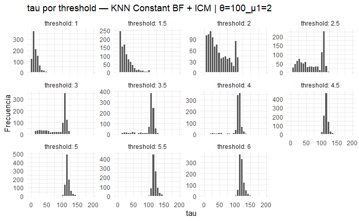

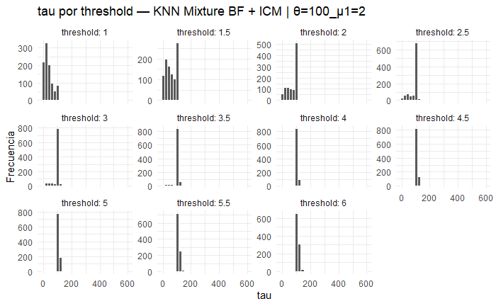

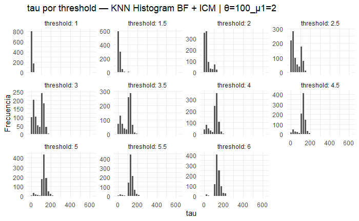

# Valor esperado y box-plot